# A large language model-assisted education tool to provide feedback on open-ended responses

Jordan K. Matelsky

Felipe Parodi

Tony Liu

Richard D. Lange

Konrad P. Kording

Large language models | Automated learning assessment |  
Automated grading | Education

matelsky@seas.upenn.edu

# Introduction

Open-ended questions — questions that require students to produce multi-word, nontrivial responses — are a popular assessment tool in educational environments because they offer students the chance to explore their understanding of learning material. Such questions provide valuable insight into students’ grasp of complex concepts and their problem-solving approaches. However, grading open-ended questions can be time-consuming, subjective, and — especially in the case of large class sizes — prone to attentional errors. These factors create a critical bottleneck in precision education.

Large Language Models (LLMs) present an opportunity to automate and promote equity in learning assessments, providing rapid valuable feedback to students while reducing the burden on instructors. We developed a tool that automatically assesses students’ responses to open-ended questions by evaluating their responses against a set of instructor-defined criteria. To use our tool, the instructor poses a question along with optional grading criteria. Students respond to these questions, and their answers are relayed to a server. The responses are paired with the grading criteria (which are not revealed to the student), forming a payload for a large language model (LLM). The LLM then generates automated feedback, suggesting areas for improvement to the student.

Here, we describe the technical design of our tool, *FreeText*, and showcase its utility in educational environments spanning topics and complexity. We further outline the implications of our work for teaching complex subjects, and the potential role of large language models in education (**Fig. 1)**. We share our source code and a public URL (see *Supplemental Materials*), allowing educators to experiment with *FreeText* firsthand.

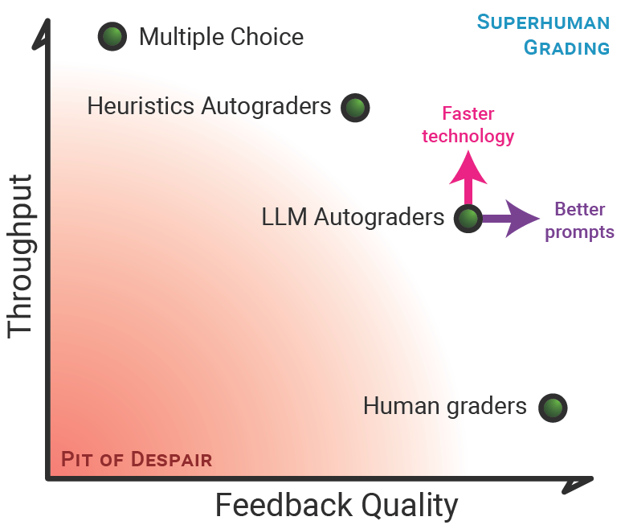

# Related Work

Automated grading is a longstanding pursuit in the field of education technology. Early automated grading tools focused on ‘solvable’ tasks like math or programming assignments, where grading generally relies on unit tests or direct output comparisons (Hollingsworth 1960; Ureel II and Wallace 2019; Orr and Russell 2021; Messer et al. 2023). These approaches often overlook less easily-quantified but nonetheless critical indicators of learning and understanding, such as design quality, code maintainability, or potential areas of student confusion. Modern tools, like AutoGrader, which provides real-time grading for programming exercises, remain narrowly focused on output correctness and do not sufficiently account for documentation or maintainability (Liu et al. 2019).

Assessing students’ understanding from natural language responses, however, presents different challenges and has seen significant evolution. Early Automated Short Answer Grading (ASAG) models employed statistical or domain-specific neural network approaches (Heilman and Madnani 2013; Riordan et al. 2017; Sung et al. 2019). In recent years, LLMs have been shown to outperform domain-specific language models (Radford et al. 2019; T. Mizumoto et al. 2019; Brown et al. 2020; Chung et al. 2022). LLMs facilitate grading of open-ended assignment responses, without the need for task-specific fine-tuning (Cao 2023; A. Mizumoto and Eguchi 2023; Yoon 2023). However, (Kortemeyer 2023) revealed that while LLMs like GPT-4 could be useful for preliminary grading of introductory physics assignments, they fell short for natural-language responses required in comprehensive exam grading. Further, while LLMs like GitHub Copilot streamline the process of code generation and review, they can fall short on more nuanced programming tasks and open-ended evaluation (Finnie-Ansley et al. 2022). Thus, in their current state, LLMs should be treated as a useful but fallible tool, with final assessments still in the hands of (human) instructors.

It is also important to consider how students perceive AI graders and how automated graders are deployed to educational settings (Burrows, Gurevych, and Stein 2015; Saha et al. 2019; Zhu, Wu, and Zhang 2022). Many comment on the socio-technical dynamics of automated grading, including the potential for introduction of machine bias (e.g., (Hsu et al. 2021)). The use of NLP for short answer grading is not a trivial task and has been set as an evaluation challenge in its own right (Dzikovska et al. 2013).

To address the evolving needs of grading open-ended responses, our framework proposes four key enhancements. First, it is specifically designed for open-ended questions, which are not typically well-served by the rubric-based grading of most ed-tech tools. Second, our system leverages LLMs to deliver rapid, personalized feedback for student responses without explicitly attempting to produce a quantitative grade. Third, our framework introduces a feedback loop to continually improve instructor-provided prompts, question suggestions, and grading criteria. Lastly, our tool integrates with the Jupyter Notebook environment, extensively utilized in fields such as computer science, data science, and statistics.

# Approach

Our software is packaged as a Python library. LLM interactions are handled by the *Guidance* Python package (Microsoft 2023). User interfaces and a JSON HTTP API are supported by FastAPI (Lathkar 2023). We support traditional (e.g., JSON files, SQLite) as well as cloud-based data storage drivers. Our server can be run at low financial and computational cost through the combination of serverless deployment (e.g., to AWS Lambda) and serverless databases (e.g., AWS DynamoDB). Student responses are not stored by *FreeText* infrastructure by default.

Any *Guidance*-compatible LLM may be swapped into the Freetext server. That is, by default we access LLMs through the OpenAI API, but it is easy to swap in locally hosted or fine-tuned models: thus, privileged or sensitive information may be kept to on-premise compute resources, or users may opt to change which API-based LLM is accessed. For example, a more powerful LLM may be selected in cases where course content is particularly complex, or a simpler model may be used for more elementary course content.

One front-end that students can access is a Jupyter Notebook widget, developed using IPyWidgets (Kluyver et al. 2016), making it easy to incorporate natural language short-answer questions as part of a notebook-based active-learning environment.

The widget communicates with the backend Python server described above. The widget is designed to be easily integrated into lecture and homework notebooks, enabling instructors to easily enrich existing teaching materials. A distinctive feature of our system is the intermediary server which equips the large language model with ‘held-out’ information, such as a rubric for correct responses, accessible only to the LLM and instructor, and not to the student. This establishes the useful informational asymmetry between the evaluator and the student.

To include the widget in a Python environment, the instructor can include the following code:

```
!pip install freetext_jupyter
from freetext_jupyter import FreetextWidget

FreetextWidget(
    # This ID is generated by the instructor.
    "07b2c3ef-0f97-46bc-a11e-..."
)
```

When executed in a Jupyter notebook cell, this code will access the HTTP API to replace the widget with the corresponding question text for the student. Upon encountering the widget in a notebook, the student is presented with an open-ended question accompanied by a text box for response input. When they submit their response, the system transmits it to the server for combination with the feedback criteria set by the instructor.

[figure not shown]

Our tool is designed to be easily deployable and scalable. The *FreeText* server can be run in resource-constrained or serverless platforms such as AWS Lambda. This allows for easy deployment and scaling, which is particularly important for large-scale projects and massive-scale courses (Viegen et al. 2021). Our API can also be combined with other existing educational tools in order to capture and store student responses for instructor review.

## Question Design

Instructors can provide a question for students to answer — either programmatically, by accessing our HTTP API — or graphically in the browser using the simple web application UI. Instructors can also provide optional assessment criteria — text like *“make sure the student mentions DNA base pairs in their answer.”*

*FreeText* can use question content to automatically establish grading criteria, or it can use the assessment criteria to improve the text of the question. The latter process works by asking the AI to serve as a student and answer a question while oblivious to the instructor’s grading criteria. Then, the answer is automatically evaluated by a separate instantiation of the LLM — this time, against the instructor criteria. The assessment model determines if the student has been unfairly penalized due to omission of requirements (or a lack of clarity) in the original question text. If so, the question is updated to better encompass the requirements of the grading criteria.

This process of iteratively incorporating assessment criteria is subtly different from simply including the criteria in the question text: For example, if the question text is, *“What is the Rosetta Stone?”* and the criteria include, *“Mention why the Ptolemaic dynasty created the Rosetta Stone”*, a *bad* question update would be to explicitly ask about the Egyptian political system, as this gives the student more information than the instructor originally intended. A *better* question update would be *“Explain what the Rosetta Stone is and the context of its creation,”* because this nudges the student to discuss the right material but does not give any new information.

## Question Presentation

There are two built-in methods to present questions to students: the first is a simple web API, which can be used standalone, coupled with response-collection tools, or embedded within other web applications. The second is a Jupyter Notebook widget that can be embedded in tutorial coding notebooks.

The JSON web API endpoints may be accessed directly by application code, or students can access a simple web user interface. This interface comprises a question display and a textbox for student responses (see *Supplemental Materials*). Feedback to students is rendered beneath the response box upon answer submission, and students may reuse the same page to resubmit amended answers.

The Jupyter Notebook widget is designed to make it easy for instructors to include open-ended questions in their assignments and subject the grading of student responses to custom grading criteria. This flexibility makes it easy for instructors to tailor the tool to their specific needs and teaching style.

## Feedback to Students

Our tool provides two types of feedback to students. The first is a holistic text response that provides feedback on the entire answer as a whole. The second is span-bound feedback (referring to a specific substring of the response) that can be used to highlight specific parts of the text that are erroneous or otherwise need student attention. For example, if a student’s answer is correct but they misattribute a quote, the *FreeText* server could highlight the attribution specifically to give feedback. The type of feedback returned can be specified by the instructor during question creation.

# Discussion

Here we introduced *FreeText*, a framework capable of defining questions, collecting student responses, transmitting these responses alongside instructor expectations to a large language model (LLM), and generating rapid and personalized feedback for the students. Notably, the entirety of the student-facing workflow can be encapsulated within a Jupyter notebook, facilitating real-time enhancement of students’ understanding of the course material. *FreeText* is not confined to a web application and Jupyter notebooks, or the academic subjects mentioned above. The *FreeText* Server can integrate with any application that consumes a JSON HTTP API, expanding its potential to a wider range of educational settings.

Our system’s broad applicability becomes evident when considering diverse learning models, such as the pod-based approach adopted by the online course Neuromatch Academy (Viegen et al. 2021) in the field of computational neuroscience. In such settings, small student groups or ‘pods’ collaboratively tackle assignments and projects. Teaching Assistants, tasked with providing feedback, can benefit from our tool, as it can streamline grading processes, reducing potential for attentional errors and freeing up instructors to deliver more personalized guidance to students.

Fully automated student evaluation is challenging both from a technical perspective and from a human perspective, and thus *FreeText* is designed not to fully automate grading, but to serve as a useful tool benefiting both students and instructors. *FreeText* benefits students by providing rapid and personalized feedback on short-answer questions. *FreeText* benefits instructors by helping them to design better questions and grading criteria, by providing first-pass material for learning assessments, and by alleviating some of the burden of providing individualized instruction in large classes. LLMs in general, and *FreeText* specifically, are not a replacement human instructors, but they can nonetheless fill a niche among education technologies.

LLMs undoubtedly hold immense power and potential. However, it is crucial to have an in-depth discussion about their ethical implications, especially in education. A key issue to consider is the potential biases that LLMs can introduce. These biases could unintentionally touch on sensitive subjects or unintentionally overlook marginalized groups. Instructors have a role to play by carefully designing their questions and assessment criteria. Further, students should be made aware of the nature of the system they are interacting with and its potential to make mistakes or act on internalized biases (Hsu et al. 2021). On the other hand, automated systems such as *FreeText* present an opportunity to reduce instructors’ unconscious biases by evaluating all students’ responses equally and without any explicit identification.

Furthermore, we must consider the broader dynamics of the AI ecosystem. The realm of LLMs is not limited to the offerings of large AI conglomerates like OpenAI. A burgeoning industry of alternative LLMs, both from smaller commercial entities and open-source initiatives (Anthropic 2023; Taori et al. 2023; Touvron et al. 2023; Wolf et al. 2020), is flourishing. Our framework is designed to be model-agnostic and can be readily adapted to integrate these alternative models.

Reliance solely on models from a single entity such as OpenAI raises two significant concerns. First, it centralizes the concentration of AI development resources and power, thereby exacerbating the already pronounced inequalities in the global AI landscape. Second, it can lead to a homogenization of the knowledge and perspectives propagated by AI models, potentially resulting in a limited and biased worldview. *FreeText* is therefore *deliberately* agnostic to the underlying LLM model and technologies.

We intend for our tool to enrich and expand students’ educational experience, particularly in large-scale or resource-constrained course settings where detailed human intervention may be limited. Ongoing work includes the careful critique and evaluation of *FreeText* outputs by expert instructors, taking advantage of upcoming opportunities to apply this technology in a large class setting.

Embracing both technical as well as human diversity helps mitigate many of the concerns raised above and enriches the AI ecosystem. A broad range of perspectives stalls the monopolization of AI technology and fosters a more balanced, equitable, and robust AI landscape. This viewpoint aligns with our belief in the need for broad and diverse human inputs, both in the creation of AI models and in their applications in society.

[figure not shown]

# Supplemental Materials

Full-resolution versions of all images and tables from this publication are available at https://llm4edu.experiments.kordinglab.com/paper.

The FreeText server will be hosted temporarily for public use at https://llm4edu.experiments.kordinglab.com/app, with an interactive example assignment available at https://llm4edu.experiments.kordinglab.com/app/assignments/1393754a-d80f-474d-bff7-b1fec36cdbb7. Educators may contact us at the correspondence email of this preprint for a token, which is required to create new questions on our public instance.

Our Jupyter Notebook Widget is available on GitHub at https://github.com/KordingLab/freetext-jupyter, and is powered by the FreeText Server, which can be found at https://github.com/KordingLab/llm4teach-freetext-server.

# Acknowledgements

Research in this publication was supported by the National Institutes of Health under award number UC2-NS128361. The content is solely the responsibility of the authors and does not necessarily represent the official views of the National Institutes of Health.

# Bibliography

Anthropic. 2023. “Claude.” https://www.anthropic.com.

Brown, Tom, Benjamin Mann, Nick Ryder, Melanie Subbiah, Jared D Kaplan, Prafulla Dhariwal, Arvind Neelakantan, et al. 2020. “Language Models Are Few-Shot Learners.” In *Advances in Neural Information Processing Systems*, 33:1877–1901. Curran Associates, Inc.

Burrows, Steven, Iryna Gurevych, and Benno Stein. 2015. “The Eras and Trends of Automatic Short Answer Grading.” *International Journal of Artificial Intelligence in Education* 25: 60–117.

Cao, Chen. 2023. “Leveraging Large Language Model and Story-Based Gamification in Intelligent Tutoring System to Scaffold Introductory Programming Courses: A Design-Based Research Study.” arXiv. https://doi.org/10.48550/arXiv.2302.12834.

Chung, Hyung Won, Le Hou, Shayne Longpre, Barret Zoph, Yi Tay, William Fedus, Yunxuan Li, et al. 2022. “Scaling Instruction-Finetuned Language Models.” arXiv. https://doi.org/10.48550/arXiv.2210.11416.

Dzikovska, Myroslava O, Rodney Nielsen, Chris Brew, Claudia Leacock, Danilo Giampiccolo, Luisa Bentivogli, Peter Clark, Ido Dagan, and Hoa Trang Dang. 2013. “Semeval-2013 Task 7: The Joint Student Response Analysis and 8th Recognizing Textual Entailment Challenge.” In *Second Joint Conference on Lexical and Computational Semantics (* SEM), Volume 2: Proceedings of the Seventh International Workshop on Semantic Evaluation (SemEval 2013)*, 263–74.

Finnie-Ansley, James, Paul Denny, Brett A Becker, Andrew Luxton-Reilly, and James Prather. 2022. “The Robots Are Coming: Exploring the Implications of Openai Codex on Introductory Programming.” In *Proceedings of the 24th Australasian Computing Education Conference*, 10–19.

Heilman, Michael, and Nitin Madnani. 2013. “ETS: Domain Adaptation and Stacking for Short Answer Scoring.” In *Second Joint Conference on Lexical and Computational Semantics (*SEM), Volume 2: Proceedings of the Seventh International Workshop on Semantic Evaluation (SemEval 2013)*, 275–79. Atlanta, Georgia, USA: Association for Computational Linguistics.

Hollingsworth, Jack. 1960. “Automatic Graders for Programming Classes.” *Communications of the ACM* 3 (10): 528–29. https://doi.org/10.1145/367415.367422.

Hsu, Silas, Tiffany Wenting Li, Zhilin Zhang, Max Fowler, Craig Zilles, and Karrie Karahalios. 2021. “Attitudes Surrounding an Imperfect AI Autograder.” In *Proceedings of the 2021 CHI Conference on Human Factors in Computing Systems*, 1–15.

Kluyver, Thomas, Benjamin Ragan-Kelley, Fernando Pérez, Brian Granger, Matthias Bussonnier, Jonathan Frederic, Kyle Kelley, et al. 2016. “Jupyter Notebooks – a Publishing Format for Reproducible Computational Workflows.” Edited by F. Loizides and B. Schmidt. IOS Press.

Kortemeyer, Gerd. 2023. “Can an AI-Tool Grade Assignments in an Introductory Physics Course?” arXiv. https://arxiv.org/abs/2304.11221 [physics].

Lathkar, Malhar. 2023. “Getting Started with FastAPI.” In *High-Performance Web Apps with FastAPI: The Asynchronous Web Framework Based on Modern Python*, 29–64. Springer.

Liu, Xiao, Shuai Wang, Pei Wang, and Dinghao Wu. 2019. “Automatic Grading of Programming Assignments: An Approach Based on Formal Semantics.” In *2019 IEEE/ACM 41st International Conference on Software Engineering: Software Engineering Education and Training (ICSE-SEET)*, 126–37. https://doi.org/10.1109/ICSE-SEET.2019.00022.

Messer, Marcus, Neil C. C. Brown, Michael Kölling, and Miaojing Shi. 2023. “Automated Grading and Feedback Tools for Programming Education: A Systematic Review.” arXiv. https://arxiv.org/abs/2306.11722 [cs].

Microsoft. 2023. “Guidance.” https://github.com/microsoft/guidance.

Mizumoto, Atsushi, and Masaki Eguchi. 2023. “Exploring the Potential of Using an AI Language Model for Automated Essay Scoring.” *Research Methods in Applied Linguistics* 2 (2): 100050. https://doi.org/10.1016/j.rmal.2023.100050.

Mizumoto, Tomoya, Hiroki Ouchi, Yoriko Isobe, Paul Reisert, Ryo Nagata, Satoshi Sekine, and Kentaro Inui. 2019. “Analytic Score Prediction and Justification Identification in Automated Short Answer Scoring.” In *Proceedings of the Fourteenth Workshop on Innovative Use of NLP for Building Educational Applications*, 316–25. Florence, Italy: Association for Computational Linguistics. https://doi.org/10.18653/v1/W19-4433.

Orr, J Walker, and Nathaniel Russell. 2021. “Automatic Assessment of the Design Quality of Python Programs with Personalized Feedback.” *arXiv Preprint arXiv:2106.01399*.

Radford, Alec, Jeffrey Wu, Rewon Child, David Luan, Dario Amodei, and Ilya Sutskever. 2019. “Language Models Are Unsupervised Multitask Learners.”

Riordan, Brian, Andrea Horbach, Aoife Cahill, Torsten Zesch, and Chong Min Lee. 2017. “Investigating Neural Architectures for Short Answer Scoring.” In *Proceedings of the 12th Workshop on Innovative Use of NLP for Building Educational Applications*, 159–68. Copenhagen, Denmark: Association for Computational Linguistics. https://doi.org/10.18653/v1/W17-5017.

Saha, Swarnadeep, Tejas I Dhamecha, Smit Marvaniya, Peter Foltz, Renuka Sindhgatta, and Bikram Sengupta. 2019. “Joint Multi-Domain Learning for Automatic Short Answer Grading.” *arXiv Preprint arXiv:1902.09183*.

Sung, Chul, Tejas Dhamecha, Swarnadeep Saha, Tengfei Ma, Vinay Reddy, and Rishi Arora. 2019. “Pre-Training BERT on Domain Resources for Short Answer Grading.” In *Proceedings of the 2019 Conference on Empirical Methods in Natural Language Processing and the 9th International Joint Conference on Natural Language Processing (EMNLP-IJCNLP)*, 6071–75. Hong Kong, China: Association for Computational Linguistics. https://doi.org/10.18653/v1/D19-1628.

Taori, Rohan, Ishaan Gulrajani, Tianyi Zhang, Yann Dubois, Xuechen Li, Carlos Guestrin, Percy Liang, and Tatsunori B Hashimoto. 2023. “Alpaca: A Strong, Replicable Instruction-Following Model.” *Stanford Center for Research on Foundation Models. Https://Crfm. Stanford. Edu/2023/03/13/Alpaca. Html* 3 (6): 7.

Touvron, Hugo, Louis Martin, Kevin Stone, Peter Albert, Amjad Almahairi, Yasmine Babaei, Nikolay Bashlykov, et al. 2023. “Llama 2: Open Foundation and Fine-Tuned Chat Models.” *arXiv Preprint arXiv:2307.09288*.

Ureel II, Leo C., and Charles Wallace. 2019. “Automated Critique of Early Programming Antipatterns.” In *Proceedings of the 50th ACM Technical Symposium on Computer Science Education*, 738–44. SIGCSE ’19. New York, NY, USA: Association for Computing Machinery. https://doi.org/10.1145/3287324.3287463.

Viegen, Tara van, Athena Akrami, Kathryn Bonnen, Eric DeWitt, Alexandre Hyafil, Helena Ledmyr, Grace W Lindsay, et al. 2021. “Neuromatch Academy: Teaching Computational Neuroscience with Global Accessibility.” *Trends in Cognitive Sciences* 25 (7): 535–38.

Wolf, Thomas, Lysandre Debut, Victor Sanh, Julien Chaumond, Clement Delangue, Anthony Moi, Perric Cistac, et al. 2020. “Transformers: State-of-the-Art Natural Language Processing.” In, 38–45. Association for Computational Linguistics. https://www.aclweb.org/anthology/2020.emnlp-demos.6.

Yoon, Su-Youn. 2023. “Short Answer Grading Using One-Shot Prompting and Text Similarity Scoring Model.” arXiv. https://arxiv.org/abs/2305.18638 [cs].

Zhu, Xinhua, Han Wu, and Lanfang Zhang. 2022. “Automatic Short-Answer Grading via BERT-Based Deep Neural Networks.” *IEEE Transactions on Learning Technologies* 15 (3): 364–75.